# Polynomial fitting

```r
library(ggplot2)
library(dplyr)
```

## Generate some data from a known 3rd-degree polynomial function

Using the equation: y = ax^3 + bx^2 + cx + d

Set a and d to arbitrary positive numbers and b, c to 0. Choose an x range from 0 to 100 in 0.1 increments. Calculate and plot y.

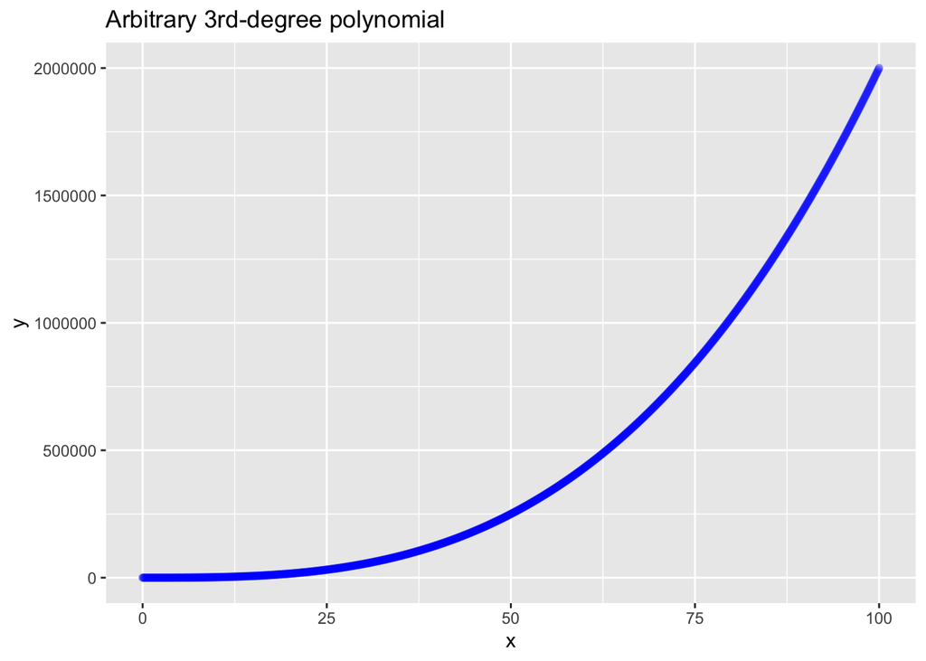

```r
a <- 2
b <- 0
c <- 0
d <- 6
x <- seq(0,100,0.1)
y <- a*x^3 + b*x^2 + c*x + d
df_arbitrary <- bind_cols(x=x, y=y)
sample_plot <- ggplot(df_arbitrary, aes(x=x, y=y)) + geom_point(alpha=0.3, color = "blue") + ggtitle("Arbitrary 3rd-degree polynomial")
sample_plot
```

## Example of fitting polynomials from R docs

The lm function can be used to fit polynomials of varying degree.

Here 4 different best fits are determined for the relationship between stopping distance and speed using the built-in cars dataset.

ANOVA is used to evaluate the best fitting function.

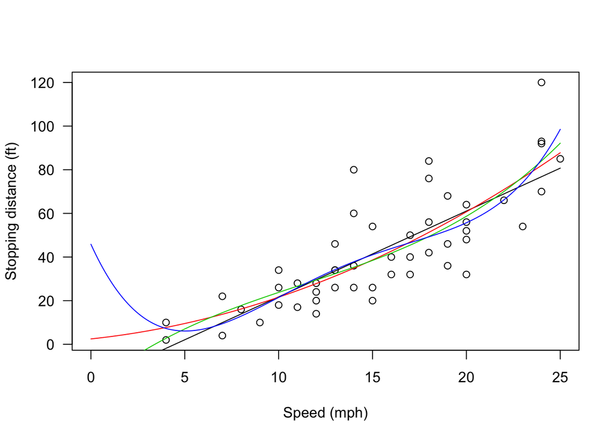

```r
## An example of polynomial regression
plot(cars, xlab = "Speed (mph)", ylab = "Stopping distance (ft)",
    las = 1, xlim = c(0, 25))

# generate x values for fit lines
d_speed <- seq(0, 25, length.out = 200)

# fit different degree polynomials
for(degree in 1:4) {
  fm <- lm(dist ~ poly(speed, degree, raw=TRUE), data = cars)
  # create variable to hold results
  assign(paste("cars", degree, sep = "."), fm)
  lines(d_speed, predict(fm, data.frame(speed = d_speed)), col = degree)
}
```

```r
anova(cars.1, cars.2, cars.3, cars.4)
```

|  | Res.Df | RSS | Df | Sum of Sq | F | Pr(>F) |
| --- | --- | --- | --- | --- | --- | --- |
| 1 | 48 | 11353.52 | NA | NA | NA | NA |
| 2 | 47 | 10824.72 | 1 | 528.8051 | 2.3108037 | 0.1354734 |
| 3 | 46 | 10634.36 | 1 | 190.3540 | 0.8318201 | 0.3666071 |
| 4 | 45 | 10297.82 | 1 | 336.5460 | 1.4706585 | 0.2315700 |

## Applying polynomial fitting to arbitrary data

### 1. Leaving coefficents unspecified

Here we use poly(x, 3, raw=TRUE) to restrict the fit to a 3rd-degree polynomial and recover the “raw” coefficients (otherwise we would get coefficients for the “orthogonal polynomial” which we do not want here)

The summary shows that the middle coefficients (b and c) are correctly determined to be close to 0.

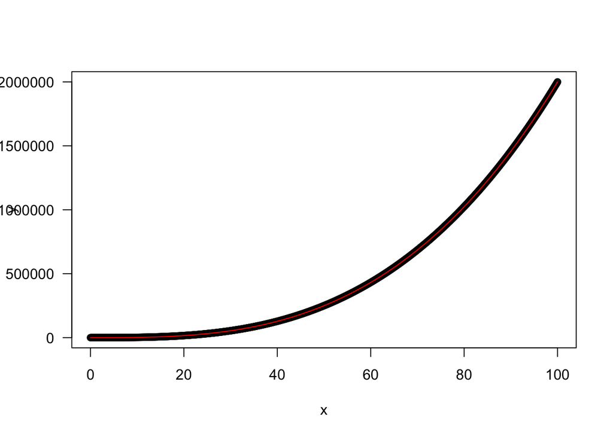

```r
## Try to fit without specifying coefficients

plot(df_arbitrary, xlab = "x", ylab = "y",
    las = 1)

mypoly <- poly(x, 3, raw = TRUE)
fit_open <- lm(y ~ mypoly, data = df_arbitrary)

# add the fit line to the plot and print the summary
lines(x, predict(fit_open, data.frame(x = x)), col = "red")
```

```r
summary(fit_open)
```

```
##
## Call:
## lm(formula = y ~ mypoly, data = df_arbitrary)
##
## Residuals:
##        Min         1Q     Median         3Q        Max
## -4.951e-10 -1.228e-11 -1.980e-12  6.080e-12  1.457e-09
##
## Coefficients:
##               Estimate Std. Error    t value Pr(>|t|)
## (Intercept)  6.000e+00  7.023e-12  8.544e+11  < 2e-16 ***
## mypoly1     -3.808e-12  6.085e-13 -6.258e+00 5.77e-10 ***
## mypoly2      7.883e-14  1.414e-14  5.573e+00 3.22e-08 ***
## mypoly3      2.000e+00  9.297e-17  2.151e+16  < 2e-16 ***
## ---
## Signif. codes:  0 '***' 0.001 '**' 0.01 '*' 0.05 '.' 0.1 ' ' 1
##
## Residual standard error: 5.575e-11 on 997 degrees of freedom
## Multiple R-squared:      1,  Adjusted R-squared:      1
## F-statistic: 3.46e+34 on 3 and 997 DF,  p-value: < 2.2e-16
```

### 2. Constraining the middle coefficients to be 0

Using the “I” notation we can specify the model to be of the form ax^3 + d. (The intercept is implied in the I notation; if we wanted to constrain that to be 0 as well, we could say lm(y ~ I(x^3) ~ 1))

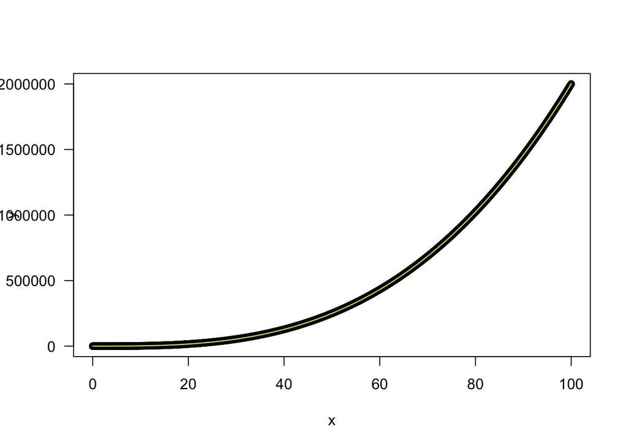

```r
plot(df_arbitrary, xlab = "x", ylab = "y",
    las = 1)
fit_spec <- lm(y ~ I(x^3), data = df_arbitrary)
lines(x, predict(fit_spec, data.frame(x = x)), col = "yellow")
```

```r
summary(fit_spec)
```

```
##
## Call:
## lm(formula = y ~ I(x^3), data = df_arbitrary)
##
## Residuals:
##        Min         1Q     Median         3Q        Max
## -1.918e-10 -4.080e-11 -3.120e-11 -6.900e-12  1.982e-08
##
## Coefficients:
##              Estimate Std. Error   t value Pr(>|t|)
## (Intercept) 6.000e+00  2.653e-11 2.262e+11   <2e-16 ***
## I(x^3)      2.000e+00  7.010e-17 2.853e+16   <2e-16 ***
## ---
## Signif. codes:  0 '***' 0.001 '**' 0.01 '*' 0.05 '.' 0.1 ' ' 1
##
## Residual standard error: 6.296e-10 on 999 degrees of freedom
## Multiple R-squared:      1,  Adjusted R-squared:      1
## F-statistic: 8.14e+32 on 1 and 999 DF,  p-value: < 2.2e-16
```

### Trying it on more realistic data

The dataset size is reduced to 100 and gaussian noise with a SD of 100 is added

The fit is still determined with good confidence in the coefficient, but less confidence in the intercept (perhaps because noise disproportionately affects smaller values of y)

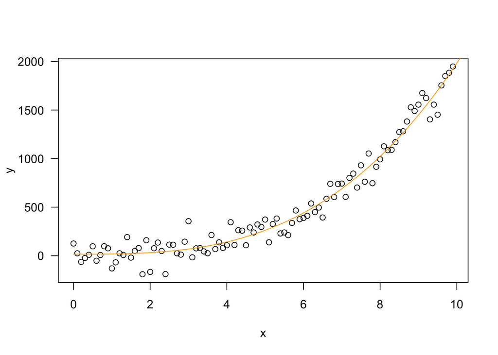

```r
# Add noise and reduce size of dataset
noise <- rnorm(100, mean=0, sd = 100)
noisy_y <- df_arbitrary$y[1:100] + noise

df_noisy <- bind_cols(x = df_arbitrary$x[1:100], y = noisy_y)
plot(df_noisy, xlab = "x", ylab = "y",
    las = 1)
fit_noisy <- lm(y ~ I(x^3), data = df_noisy)
lines(x, predict(fit_noisy, data.frame(x = x)), col = "orange")
```

```r
summary(fit_noisy)
```

```
##
## Call:
## lm(formula = y ~ I(x^3), data = df_noisy)
##
## Residuals:
##      Min       1Q   Median       3Q      Max
## -249.650  -51.740    5.219   72.034  286.447
##
## Coefficients:
##             Estimate Std. Error t value Pr(>|t|)
## (Intercept) 15.93110   13.26636   1.201    0.233
## I(x^3)       1.96634    0.03572  55.043   <2e-16 ***
## ---
## Signif. codes:  0 '***' 0.001 '**' 0.01 '*' 0.05 '.' 0.1 ' ' 1
##
## Residual standard error: 99.69 on 98 degrees of freedom
## Multiple R-squared:  0.9687, Adjusted R-squared:  0.9683
## F-statistic:  3030 on 1 and 98 DF,  p-value: < 2.2e-16
```

```r
coefficients(fit_noisy)
```

```
## (Intercept)      I(x^3)
##   15.931098    1.966338
```